# Herbivory_experiment_0824

# **4.2. Relative growth rate of caterpillars(RGR)**

Make scatterplots of built-up ratio and relative growth rate of caterpillars(RGR).

# **4.2.1. Based on all observations**

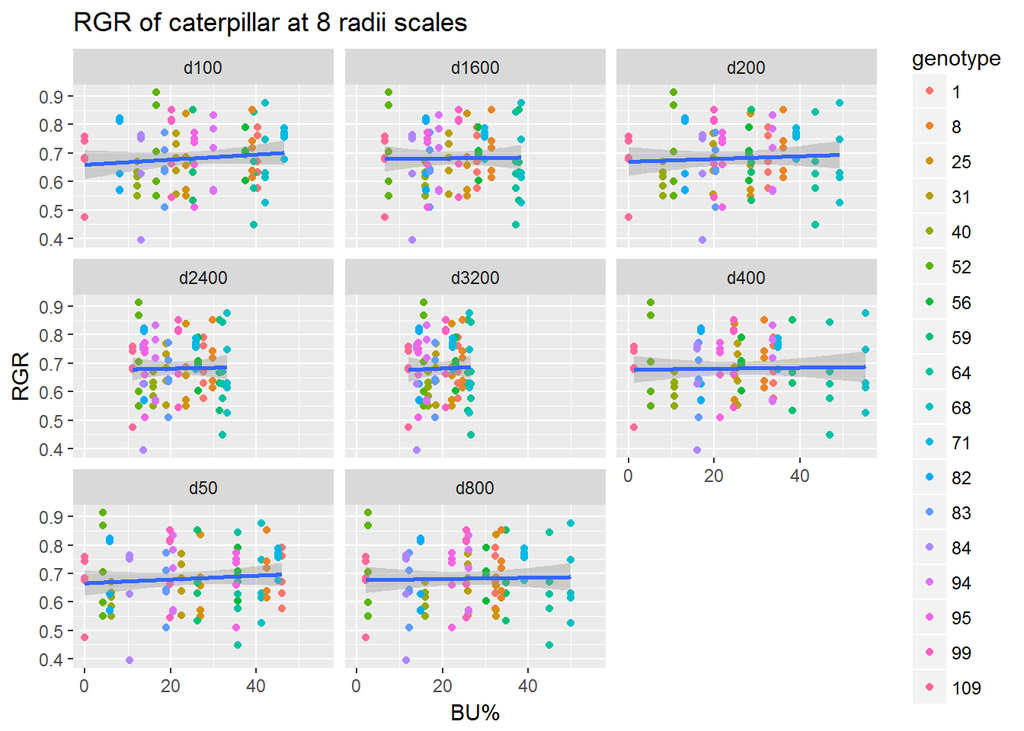

```r
# use available dataframe "herbivory.BU.L"
## create plots of RGR and spatial scales based on all individual obserations


# create plot
p.RGR <- ggplot(herbivory.BU.L) +
  geom_point(mapping = aes(x = ratio.bu, y = RGR, colour = genotype)) +
  facet_wrap(~ radii, nrow = 3) +
  labs(title = "RGR of caterpillar at 8 radii scales", x = "BU%", y = "RGR") +
  geom_smooth(mapping = aes(x = ratio.bu, y = RGR), method='lm')
p.RGR
```

```r
#make lm models
mod.RGR50 <- lm(herbivory.BU, formula = RGR ~ d50)
mod.RGR100 <- lm(herbivory.BU, formula = RGR ~ d100)
mod.RGR200 <- lm(herbivory.BU, formula = RGR ~ d200)
mod.RGR400 <- lm(herbivory.BU, formula = RGR ~ d400)
mod.RGR800 <- lm(herbivory.BU, formula = RGR ~ d800)
mod.RGR1600 <- lm(herbivory.BU, formula = RGR ~ d1600)
mod.RGR2400 <- lm(herbivory.BU, formula = RGR ~ d2400)
mod.RGR3200 <- lm(herbivory.BU, formula = RGR ~ d3200)

AIC(mod.RGR50, mod.RGR100, mod.RGR200, mod.RGR400, mod.RGR800, mod.RGR1600, mod.RGR2400, mod.RGR3200)     #### d100 has lowest AIC score.
```

```
##             df       AIC
## mod.RGR50    3 -141.8196
## mod.RGR100   3 -142.1200
## mod.RGR200   3 -141.3608
## mod.RGR400   3 -141.1155
## mod.RGR800   3 -141.1350
## mod.RGR1600  3 -141.0904
## mod.RGR2400  3 -141.1049
## mod.RGR3200  3 -141.1392
```

```r
summary(mod.RGR100)
```

```
##
## Call:
## lm(formula = RGR ~ d100, data = herbivory.BU)
##
## Residuals:
##       Min        1Q    Median        3Q       Max
## -0.277318 -0.078320  0.001061  0.084641  0.240171
##
## Coefficients:
##              Estimate Std. Error t value Pr(>|t|)
## (Intercept) 0.6594013  0.0253042  26.059   <2e-16 ***
## d100        0.0009006  0.0008860   1.017    0.312
## ---
## Signif. codes:  0 '***' 0.001 '**' 0.01 '*' 0.05 '.' 0.1 ' ' 1
##
## Residual standard error: 0.1075 on 88 degrees of freedom
## Multiple R-squared:  0.01161,    Adjusted R-squared:  0.0003744
## F-statistic: 1.033 on 1 and 88 DF,  p-value: 0.3122
```

Results: By making ‘lm’ models at different spatial scales and then comparing the AIC values of all models on ‘relative growth rate of caterpillars(RGR)’, the result shows that the model at 100m scale, with positive but not significant linear correlation (p=0.3122) of RGR of caterpillars and urbanisation, is best. Scatterplots are dispersed, but with very low R2.

# **4.2.2. Based on average data on RGR of each mother plant**

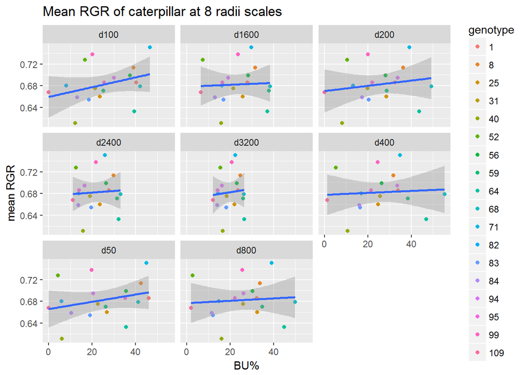

```r
# calculate mean RGR of caterpillars
mean.RGR <- ddply(herbivory.BU, "genotype", summarise,
                  mean.RGR = mean(RGR)
                  )


# combine spatial data with data on mean RGR
RGR.BU <- merge(mean.RGR, BU, by = "genotype")
View(RGR.BU)

# gather data
RGR.BU.L <- gather(RGR.BU, `d50`, `d100`, `d200`, `d400`, `d800`, `d1600`, `d2400`, `d3200`,
       key = "radii", value = "ratio.bu")
View(RGR.BU.L)

# create the plot
p.mRGR <- ggplot(RGR.BU.L) +
  geom_point(mapping = aes(x = ratio.bu, y = mean.RGR, colour = genotype)) +
  facet_wrap(~ radii, nrow = 3) +
  labs(title = "Mean RGR of caterpillar at 8 radii scales", x = "BU%", y = "mean RGR") +
  geom_smooth(mapping = aes(x = ratio.bu, y = mean.RGR), method = 'lm')
p.mRGR
```

```r
#make lm models
mod.mRGR50 <- lm(RGR.BU, formula = mean.RGR ~ d50)
mod.mRGR100 <- lm(RGR.BU, formula = mean.RGR ~ d100)
mod.mRGR200 <- lm(RGR.BU, formula = mean.RGR ~ d200)
mod.mRGR400 <- lm(RGR.BU, formula = mean.RGR ~ d400)
mod.mRGR800 <- lm(RGR.BU, formula = mean.RGR ~ d800)
mod.mRGR1600 <- lm(RGR.BU, formula = mean.RGR ~ d1600)
mod.mRGR2400 <- lm(RGR.BU, formula = mean.RGR ~ d2400)
mod.mRGR3200 <- lm(RGR.BU, formula = mean.RGR ~ d3200)

AIC(mod.mRGR50, mod.mRGR100, mod.mRGR200, mod.mRGR400, mod.mRGR800, mod.mRGR1600, mod.mRGR2400, mod.mRGR3200)     #### d100 has lowest AIC score.
```

```
##              df       AIC
## mod.mRGR50    3 -65.99058
## mod.mRGR100   3 -66.63542
## mod.mRGR200   3 -65.04445
## mod.mRGR400   3 -64.55650
## mod.mRGR800   3 -64.59484
## mod.mRGR1600  3 -64.50725
## mod.mRGR2400  3 -64.53574
## mod.mRGR3200  3 -64.60322
```

```r
summary(mod.mRGR100)
```

```
##
## Call:
## lm(formula = mean.RGR ~ d100, data = RGR.BU)
##
## Residuals:
##       Min        1Q    Median        3Q       Max
## -0.062096 -0.017268  0.000058  0.012305  0.060038
##
## Coefficients:
##              Estimate Std. Error t value Pr(>|t|)
## (Intercept) 0.6594013  0.0179678  36.699   <2e-16 ***
## d100        0.0009006  0.0006291   1.432    0.172
## ---
## Signif. codes:  0 '***' 0.001 '**' 0.01 '*' 0.05 '.' 0.1 ' ' 1
##
## Residual standard error: 0.03413 on 16 degrees of freedom
## Multiple R-squared:  0.1135, Adjusted R-squared:  0.05814
## F-statistic: 2.049 on 1 and 16 DF,  p-value: 0.1715
```

Results: By making ‘lm’ models at different spatial scales and then comparing the AIC values of all models on ‘mean relative growth rate of caterpillars(RGR)’, the result shows that the model still at 100m scale, with positive but not significant linear correlation (p=0.1715) of mean RGR of caterpillars and urbanisation, is best but with very low R2.

# **4.3. Number of trichome**

Make scatterplots of built-up ratio and number of trichome.

# **4.3.1. Based on all observations**

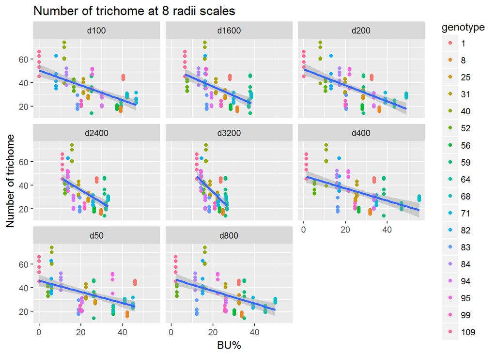

```r
# use available dataframe "herbivory.BU.L"
## create plots of number of trichome and spatial scales based on all individual obserations


# create plot
p.tric <- ggplot(herbivory.BU.L) +
  geom_point(mapping = aes(x = ratio.bu, y = trichome, colour = genotype)) +
  facet_wrap(~ radii, nrow = 3) +
  labs(title = "Number of trichome at 8 radii scales", x = "BU%", y = "Number of trichome") +
  geom_smooth(mapping = aes(x = ratio.bu, y = trichome), method='lm')
p.tric
```

```r
#make lm models
mod.tric50 <- lm(herbivory.BU, formula = trichome ~ d50)
mod.tric100 <- lm(herbivory.BU, formula = trichome ~ d100)
mod.tric200 <- lm(herbivory.BU, formula = trichome ~ d200)
mod.tric400 <- lm(herbivory.BU, formula = trichome ~ d400)
mod.tric800 <- lm(herbivory.BU, formula = trichome ~ d800)
mod.tric1600 <- lm(herbivory.BU, formula = trichome ~ d1600)
mod.tric2400 <- lm(herbivory.BU, formula = trichome ~ d2400)
mod.tric3200 <- lm(herbivory.BU, formula = trichome ~ d3200)

AIC(mod.tric50, mod.tric100, mod.tric200, mod.tric400, mod.tric800, mod.tric1600, mod.tric2400, mod.tric3200)     #### d200 has lowest AIC score.
```

```
##              df      AIC
## mod.tric50    3 709.4586
## mod.tric100   3 698.6318
## mod.tric200   3 692.9292
## mod.tric400   3 708.3447
## mod.tric800   3 708.9056
## mod.tric1600  3 705.8201
## mod.tric2400  3 702.6646
## mod.tric3200  3 699.4713
```

```r
summary(mod.tric200)
```

```
##
## Call:
## lm(formula = trichome ~ d200, data = herbivory.BU)
##
## Residuals:
##     Min      1Q  Median      3Q     Max
## -20.050  -8.027  -1.395  10.034  28.118
##
## Coefficients:
##             Estimate Std. Error t value Pr(>|t|)
## (Intercept) 51.30736    2.61561  19.616  < 2e-16 ***
## d200        -0.67577    0.09338  -7.237 1.63e-10 ***
## ---
## Signif. codes:  0 '***' 0.001 '**' 0.01 '*' 0.05 '.' 0.1 ' ' 1
##
## Residual standard error: 11.12 on 88 degrees of freedom
## Multiple R-squared:  0.3731, Adjusted R-squared:  0.366
## F-statistic: 52.37 on 1 and 88 DF,  p-value: 1.63e-10
```

Results: (1) Visually, number of trichome decreases with increase in urbanisation.

2. Comparing AIC values of models, the model at 200m scale is best, with significantly negative correlation between “number of trichome” and urbanisation (p=1.63e-10, R2=0.366).